13 January 2022

# 1 Lesson 3: mutating joins 1

## 1.1 Learning objectives

1. Mutating joins functions in practice
2. pitfalls when joining data

Mutating joins are the crucial functions that you need to know when working with data relations. There are 4 main functions:

- **left_join()**
- **right_join()**
- **inner_join()**
- **full_join()**

These 4 functions share the same syntax and are considered one of the pillars of data science. Indeed, joining functions, are present in other programming languages like **Python** and **SQL** and even if the syntax might look different, the concepts are the same.

```r
library(here)
library(dplyr)
library(readr)
```

Differently from binding functions (**bind_rows()** & **bind_cols**), the mutating join functions come in handy when we need to join together dataframes with different columns.

### 1.1.1 left_join()

The concept of **left_join()** is that everything on the left dataframe is retained and joins every row that matches base on criteria from the right table. Here below you can see a visual representation of the concept.

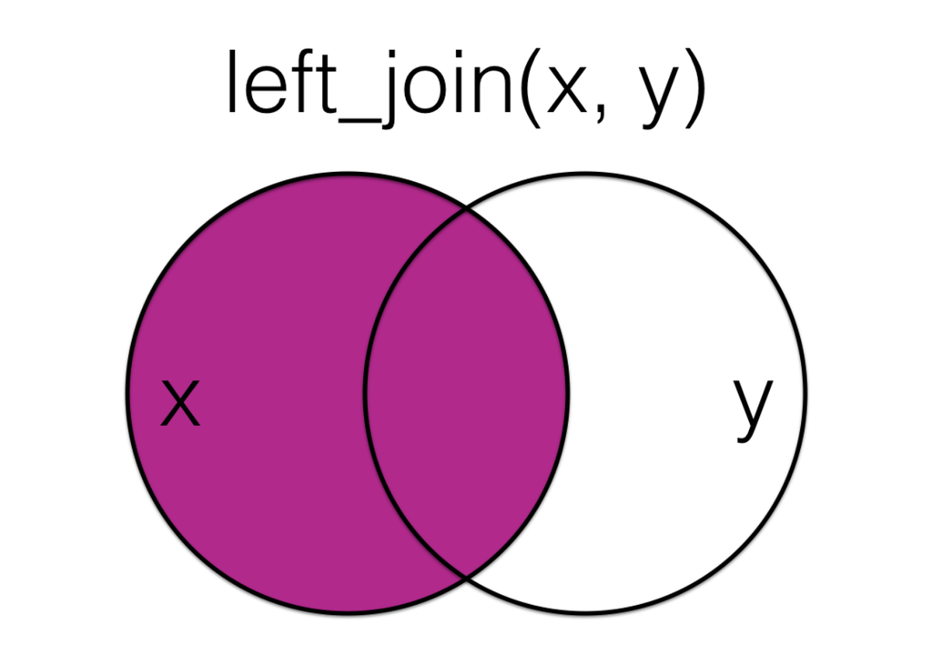

Source: [PsyTeachR](https://psyteachr.github.io/reprores-v2/joins.html)

let’s try to use this new function. For this task, we are gonna use the Yaoundé dataframe. First, we filter and select only some variables and rows from the original dataframe to ease the task.

```r
yaounde <-
  read_csv(file = here("chapter_xxx_tidy_data/data/yaounde_covid_seroprev_dataset.csv"), show_col_types = FALSE)

yaounde_1 <-
  yaounde %>%
  select("id_quest", "n_hhld_rooms", "n_hhld_adults", "n_hhld_children") %>%
  slice(2:25)

yaounde_2 <-
  yaounde %>%
  select("id_quest", "loc_hhld_area", "loc_hhld_lat", "loc_hhld_long") %>%
  slice(2:20)
```

The yaounde_1 dataframe columns refer to the number of rooms (n_hhld_rooms), adults (n_hhld_adults) and children (n_hhld_children) in a specific household, while yaounde_2 reports some geographical information about the household location i.e. name of the area (loc_hhld_area), latitude (loc_hhld_lat ) and longitude (loc_hhld_long). Both dataframes contain a unique index (id_quest) that is the criteria that we can use to join our data i.e. every row on the right dataframe will be matched with a row on the left dataframe whenever the id_quest is the same. Let’s try

```r
yaounde_lj <-
  left_join(yaounde_1, yaounde_2, by = "id_quest")

yaounde_lj
```

```
## # A tibble: 24 x 7
##    id_quest             n_hhld_rooms n_hhld_adults n_hhld_children loc_hhld_area
##    <chr>                       <dbl>         <dbl>           <dbl> <chr>
##  1 CARRIERE/NUM/002/00~            2             3               1 carriere
##  2 CARRIERE/NUM/002/00~            2             3               1 carriere
##  3 CARRIERE/NUM/038/00~            5             2               4 carriere
##  4 CARRIERE/NUM/038/00~            5             2               4 carriere
##  5 CARRIERE/NUM/015/00~            4             6               1 carriere
##  6 CARRIERE/NUM/005/00~            4             2               2 carriere
##  7 BRIQUETERIE/NUM/012~            5             8               4 briqueterie
##  8 BRIQUETERIE/NUM/019~            7             7               1 briqueterie
##  9 CARRIERE/NUM/014/00~            4             5               0 carriere
## 10 BRIQUETERIE/NUM/014~            4             6               0 briqueterie
## # ... with 14 more rows, and 2 more variables: loc_hhld_lat <dbl>,
## #   loc_hhld_long <dbl>
```

If you try to explore the resulting dataframe you will notice that yaounde_1 and yaounde_2 are joined together based on the id_quest. As mentioned above, **left_join()** keeps everything from the left dataframe, even when the dataframes have different lengths as in our case. When there are no matches with the right dataframe, the missing values are simply replaced with NA. Here you can appreciate the advantages compared to **bind_rows()** function.

If you desire you can also use more criteria to join dataframes e.g. you can write the above code as follow combining the criteria into a vector with **c()**

```r
#yaounde_lj <-
  #left_join(yaounde_1, yaounde_2, by = c("id_quest", "criteria_2", "criteria_3"))
```

When you are using multiple criteria you have to be careful and be sure that at least one of your variables can identify in a unique way your rows. The risk to consider when using **left_join()**, is that your variables might join data in a wrong way

Let’s illustrate one last scenario i.e. when the right dataframe contains more matches with the left dataframe. Here below we modify yaounde_2 by duplicating each row

```r
yaounde_2 <-
  yaounde_2 %>%
  slice(rep(1:n(), each = 2))
```

let’s the the **left_join()**

```r
yaounde_lj_duplicates <-
  left_join(yaounde_1, yaounde_2, by = "id_quest")

yaounde_lj_duplicates
```

```
## # A tibble: 43 x 7
##    id_quest             n_hhld_rooms n_hhld_adults n_hhld_children loc_hhld_area
##    <chr>                       <dbl>         <dbl>           <dbl> <chr>
##  1 CARRIERE/NUM/002/00~            2             3               1 carriere
##  2 CARRIERE/NUM/002/00~            2             3               1 carriere
##  3 CARRIERE/NUM/002/00~            2             3               1 carriere
##  4 CARRIERE/NUM/002/00~            2             3               1 carriere
##  5 CARRIERE/NUM/038/00~            5             2               4 carriere
##  6 CARRIERE/NUM/038/00~            5             2               4 carriere
##  7 CARRIERE/NUM/038/00~            5             2               4 carriere
##  8 CARRIERE/NUM/038/00~            5             2               4 carriere
##  9 CARRIERE/NUM/015/00~            4             6               1 carriere
## 10 CARRIERE/NUM/015/00~            4             6               1 carriere
## # ... with 33 more rows, and 2 more variables: loc_hhld_lat <dbl>,
## #   loc_hhld_long <dbl>
```

What we obtained is a dataframe of dimension 43 x 7. Why this? As we mentioned every row from the right dataframe is matched with the rows of the left dataframe based on a matching criteria. The right dataframe (yaounde_2) has 38 rows, where each row is duplicated (i.e. 19 unique id_quest). The left dataframe (yaounde_1) has no duplicates and consist of 24 unique rows where 19 of those have 2 matching with the right dataframe. If you do the math, you will see that the matching are 19 * 2 (because of duplicate2 in yaounde_2 ) which is equal to 38, and then you have to add the 5 rows that are present only in the left dataframe. The final result is 43, which is the length of yaounde_lj_duplicates.

Again, keep in mind that is a good practice to explore the data and have in mind the size of the expected outcome when using mutating joins functions.

Before moving to the other functions there is still one case to consider when using the **left_join()** function which is the case where the 2 dataframes have more columns in common that are not used inside the argument **by**. Let’s modify our yaounde_1 and yaounde_2

```r
yaounde_1 <-
  yaounde %>%
  select("id_quest", "n_hhld_rooms", "n_hhld_adults", "n_hhld_children", "loc_hhld_area") %>%
  slice(2:25)

yaounde_2 <-
  yaounde %>%
  select("id_quest", "loc_hhld_area", "loc_hhld_lat", "loc_hhld_long") %>%
  slice(2:20)
```

Here we simply added the variable “loc_hhld_area” to yaounde_1

```r
yaounde_lj <-
  left_join(yaounde_1, yaounde_2, by = "id_quest")

yaounde_lj
```

| id_quest | n_hhld_rooms | n_hhld_adults | n_hhld_children | loc_hhld_area.x | loc_hhld_area.y | loc_hhld_lat | loc_hhld_long |
| --- | --- | --- | --- | --- | --- | --- | --- |
| CARRIERE/NUM/002/0001 | 2 | 3 | 1 | carriere | carriere | 3.8906 | 11.491838 |
| CARRIERE/NUM/002/0002 | 2 | 3 | 1 | carriere | carriere | 3.8907 | 11.492738 |
| CARRIERE/NUM/038/0002 | 5 | 2 | 4 | carriere | carriere | 3.890196 | 11.491592 |
| CARRIERE/NUM/038/0006 | 5 | 2 | 4 | carriere | carriere | 3.890321 | 11.491791 |
| CARRIERE/NUM/015/0002 | 4 | 6 | 1 | carriere | carriere | 3.882679 | 11.485784 |
| CARRIERE/NUM/005/0002 | 4 | 2 | 2 | carriere | carriere | 3.890423 | 11.490875 |
| BRIQUETERIE/NUM/012/0001 | 5 | 8 | 4 | briqueterie | briqueterie | 3.881242 | 11.510688 |
| BRIQUETERIE/NUM/019/0004 | 7 | 7 | 1 | briqueterie | briqueterie | 3.875673 | 11.512141 |
| CARRIERE/NUM/014/0004 | 4 | 5 | 0 | carriere | carriere | 3.883122 | 11.491425 |
| BRIQUETERIE/NUM/014/0006 | 4 | 6 | 0 | briqueterie | briqueterie | 3.874846 | 11.505514 |

[output cut: 14 more lines]

When looking at the outcome you can see that both “loc_hhld_area” are retained but are also renamed with .x and .y in the name end. In this way, **left_join()** helps you to know that the 2 columns come from different dataframes. Indeed, in our example the 2 columns are actually identical, but when dealing with real data it can frequently happen that your dataframes have the same columns name but the values are different. If you like, you can personalize the way the variables are renamed with the attribute **suffix**

```r
yaounde_lj <-
  left_join(yaounde_1, yaounde_2,
            by = c("id_quest"),
            suffix = c("_yaounde_1", "_yaounde_2"))

yaounde_lj
```

| id_quest | n_hhld_rooms | n_hhld_adults | n_hhld_children | loc_hhld_area_yaounde_1 | loc_hhld_area_yaounde_2 | loc_hhld_lat | loc_hhld_long |
| --- | --- | --- | --- | --- | --- | --- | --- |
| CARRIERE/NUM/002/0001 | 2 | 3 | 1 | carriere | carriere | 3.8906 | 11.491838 |
| CARRIERE/NUM/002/0002 | 2 | 3 | 1 | carriere | carriere | 3.8907 | 11.492738 |
| CARRIERE/NUM/038/0002 | 5 | 2 | 4 | carriere | carriere | 3.890196 | 11.491592 |
| CARRIERE/NUM/038/0006 | 5 | 2 | 4 | carriere | carriere | 3.890321 | 11.491791 |
| CARRIERE/NUM/015/0002 | 4 | 6 | 1 | carriere | carriere | 3.882679 | 11.485784 |
| CARRIERE/NUM/005/0002 | 4 | 2 | 2 | carriere | carriere | 3.890423 | 11.490875 |
| BRIQUETERIE/NUM/012/0001 | 5 | 8 | 4 | briqueterie | briqueterie | 3.881242 | 11.510688 |
| BRIQUETERIE/NUM/019/0004 | 7 | 7 | 1 | briqueterie | briqueterie | 3.875673 | 11.512141 |
| CARRIERE/NUM/014/0004 | 4 | 5 | 0 | carriere | carriere | 3.883122 | 11.491425 |
| BRIQUETERIE/NUM/014/0006 | 4 | 6 | 0 | briqueterie | briqueterie | 3.874846 | 11.505514 |

[output cut: 14 more lines]

### 1.1.2 right_join()

We won’t spend much time on this function because its functioning is the same as **left_join()**, the only difference is that it retains all the elements from the right dataframe matching those from the left

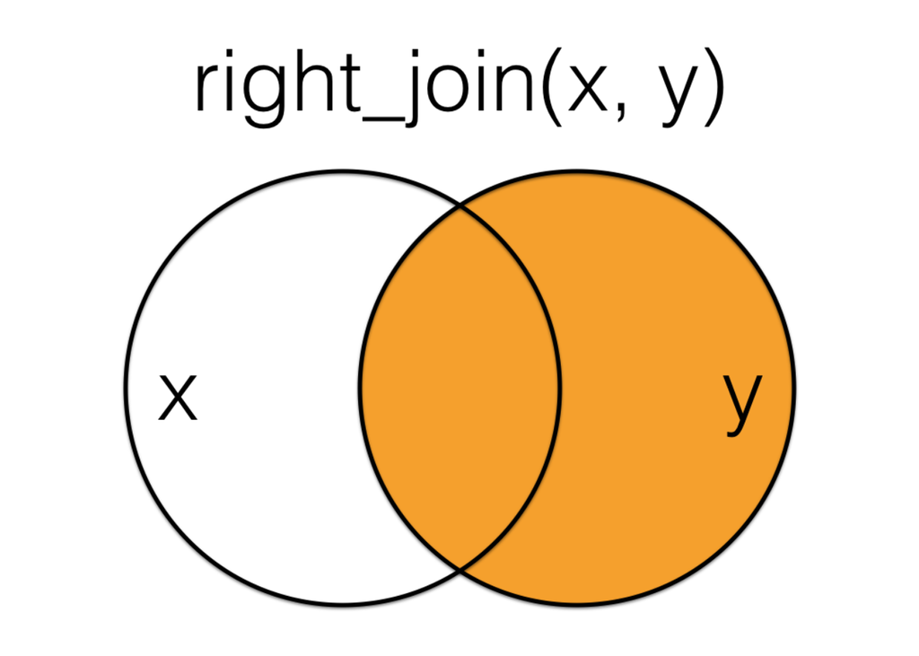

Source: [PsyTeachR](https://psyteachr.github.io/reprores-v2/joins.html)

let’s check an example with the same data we used so far

```r
yaounde_1 <-
  yaounde %>%
  select("id_quest", "n_hhld_rooms", "n_hhld_adults", "n_hhld_children") %>%
  slice(2:25)

yaounde_2 <-
  yaounde %>%
  select("id_quest", "loc_hhld_area", "loc_hhld_lat", "loc_hhld_long") %>%
  slice(2:20)
```

```r
yaounde_rj <-
  right_join(yaounde_1, yaounde_2, by = "id_quest")

yaounde_rj
```

```
## # A tibble: 19 x 7
##    id_quest             n_hhld_rooms n_hhld_adults n_hhld_children loc_hhld_area
##    <chr>                       <dbl>         <dbl>           <dbl> <chr>
##  1 CARRIERE/NUM/002/00~            2             3               1 carriere
##  2 CARRIERE/NUM/002/00~            2             3               1 carriere
##  3 CARRIERE/NUM/038/00~            5             2               4 carriere
##  4 CARRIERE/NUM/038/00~            5             2               4 carriere
##  5 CARRIERE/NUM/015/00~            4             6               1 carriere
##  6 CARRIERE/NUM/005/00~            4             2               2 carriere
##  7 BRIQUETERIE/NUM/012~            5             8               4 briqueterie
##  8 BRIQUETERIE/NUM/019~            7             7               1 briqueterie
##  9 CARRIERE/NUM/014/00~            4             5               0 carriere
## 10 BRIQUETERIE/NUM/014~            4             6               0 briqueterie
## 11 BRIQUETERIE/NUM/029~            4             3               0 briqueterie
## 12 BRIQUETERIE/NUM/029~            4             3               0 briqueterie
## 13 CARRIERE/NUM/065/00~            1             2               1 carriere
## 14 MOKOLO/NUM/019/0002             4             5               3 mokolo
## 15 BRIQUETERIE/NUM/015~            2             2               1 briqueterie
## 16 EKOUDOU/NUM/001/0001            5             2               3 ekoudou
## 17 EKOUDOU/NUM/001/0004            5             2               3 ekoudou
## 18 EKOUDOU/NUM/032/0001            2             2               2 ekoudou
## 19 EKOUDOU/NUM/002/0001            6             9               6 ekoudou
## # ... with 2 more variables: loc_hhld_lat <dbl>, loc_hhld_long <dbl>
```

As you can see, now the join is made on the right.

One important thing to know is that whether you decide to use **left_join()** or **right_join()** does not really matter but what is crucial is the position of the dataframes inside the function based on the function you choose. Let’s test an example to clarify the concept

The following 2 chunks of code provide the same result

```r
yaounde_test_rj <-
  right_join(yaounde_1, yaounde_2, by = "id_quest")
```

```r
yaounde_lj <-
  left_join(yaounde_2, yaounde_1, by = "id_quest")
```

The only difference would be the order of the columns. Differently, doing the following

```r
yaounde_test_rj <-
  right_join(yaounde_1, yaounde_2, by = "id_quest")
```

```r
yaounde_test_rj <-
  right_join(yaounde_2, yaounde_1, by = "id_quest")
```

Will lead to different result

### 1.1.3 Quizzes

to answers the following questions upload the following dataframe

```r
#source: http://ghdx.healthdata.org/gbd-results-tool?params=gbd-api-2019-public/57c9ddb333664cb85502f509ab10a84b

join_quizzes_data <-
  read_csv(file = here("chapter_xxx_tidy_data/data/join_quizzes.csv"), show_col_types = FALSE)
```

```r
q_data_1 <-
  join_quizzes_data %>%
  select(location_id, sex_id, val) %>%
  slice(1:30)

q_data_2 <-
  join_quizzes_data %>%
  select(location_id, sex_id, cause_name) %>%
  slice(250:700)

q_data_3 <-
  join_quizzes_data %>%
  select(location_id, location_name) %>%
  slice(50:100)
```

##### 1.1.3.0.1 Q1: When trying to left_join(q_data_1, q_data_2) which of the following statements is true?

```r
#delete the wrong answers
q1 <- "there are NA in the result data"
q1 <- "there are NO NA in the result data"
q1 <- "the dataframe length is = to the sum of the length of the 2 dataframes"
q1 <- "the result dimension is 1770 x 3"

.check_q1()
```

```
## Wrong. Please try again.
##   1   2
```

```r
.hint_q1()
```

```
## check the results of left_join()!
```

Q2: Why left_join with q_data_2 and q_data_3 by “location_id” returns NA in the “location_name” variable?

```r
#delete the wrong answers
q2 <- "q_data_2 and q_data_3 have different columns"
q2 <- "Lower respiratory infections data are not reported for some countries"
q2 <- "the data have different length"
q2 <- "there are missing values in join_quizzes_data"

.check_q2()
```

```
## Wrong. Please try again.
##   1   2
```

```r
.hint_q2()
```

```
## remember to use the argument 'by'
```

# Contributors

The following team members contributed to this lesson:

- [LAURE VANCAUWENBERGHE](https://thegraphnetwork.training/members/lolovanco)  
  Data analyst, the GRAPH Network

  This is a temporary tagline
- [MATTEO FRANZA](https://thegraphnetwork.training/members/mfr)  
  PhD at EPFL

  This is a temporary tagline
- [KENE DAVID NWOSU](https://thegraphnetwork.training/members/kendavidn/)  
  Data analyst, the GRAPH Network

  Passionate about data, health and education

# References

Some material in this lesson was adapted from the following sources:

- 2021-10-15, *PsyTeachR, Data Skills for Reproducible Research (v2)* ([link](https://psyteachr.github.io/reprores-v2/joins.html))